# Seminar 2.2 løsningsforslag

## Oppgave 1

Erna har nyresvikt, og personen som har to friske nyrer heter Trine. Den opprinnelige situasjonen kan tegnes slik:

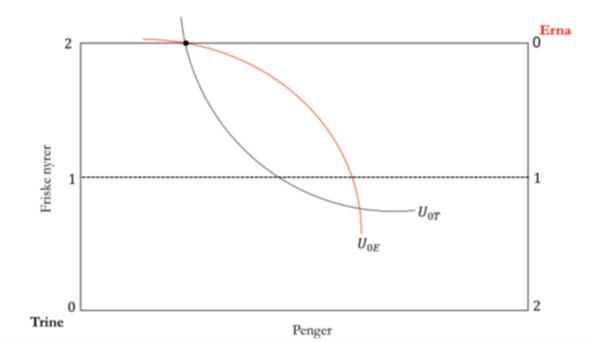

Trine oppnår da nyttenivået $U_{0T}$ og Erna $U_{0E}$.

Bruk bytteboksen videre til å vise hvordan legal handel med nyrer kan øke effektiviteten.

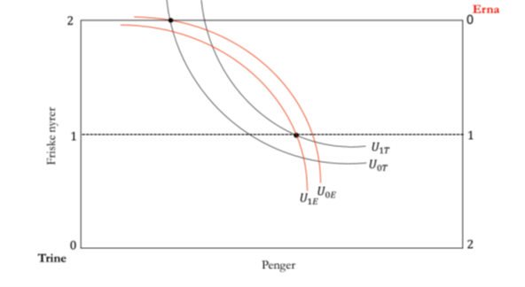

Om Trine selger en nyre og Erna kjøper den, vil begge få det bedre, altså begge oppnår høyere indifferenskurve. Denne omfordelingen er en Pareto-forbedring. Legaliseringen har økt effektiviteten, dvs. minst en person får økt velferd samtidig som ingen andre får redusert sin velferd.

Det er en haug med etiske argumenter for å forby organhandel. Likevel kan effektivitet bli bedre ved å legalisere denne handelen. Bare i USA dør det årlig 4500 mennesker mens de venter på å få en ny nyre. I verdenssammenheng antas det å være over 20 millioner som trenger transplantasjon, dialyse eller annen hjelp og over en million dør årlig av mangel på slik hjelp. Det er sterke argumenter begge veier, ta en titt på disse norske kronikker, den ene [**mot**](https://www.minervanett.no/samfunn-mennesker-redusert-prisen-pa-organene/) organhandel, den andre [**for**](https://www.dagbladet.no/kultur/kan-jeg-kjope-nyra-di/60166185)

## Oppgave 2

a. I et rent markedssystem vil et individ fortsette å investere i utdanning så lenge den private marginalnytten overstiger den private kostnaden

$$MPV(x) = MPC(x)$$

$$500 - 60x = 200 + 40x\$$

$$100x = 300\$$

$$x = 3$$
b. For samfunnet ville det vært optimalt at et individ investerte i utdanning så lenge den samfunnsøkonomiske marginalnytten overstiger den private kostnaden

$$MSV(x) = MPC(x)\$$

$$600 - 40x = 200 + 40x\$$

$$80x = 400\$$

$$x = 5$$

I et rent privat markedssystem ville det da vært underforbruk av utdanning

c. Myndighetene vil endre individets marginalkostnader ved å subsidiere slik at individet velger det samfunnsøkonomisk optimale nivået av utdanning, 5 år.

Vi finner likevekten ved å sette den samfunnsøkonomiske marginalnytten lik den private kostnaden minus subsidier

$$MPV(x) = MPC(x) - s$$

$$500 - 60x = 200 + 40x - s\$$

$$s = 100x - 300$$

Vi vet at det optimale nivået for utdanning er fem år, og setter dette inn i ligningen

$$s = 100*5 - 300$$

$$s = 200$$

Vi ser i figuren at subsidiering reduserer individets marginalkostnader at hun nå velger det samfunnsøkonomisk optimale niovået av utdanning $Q_2$.

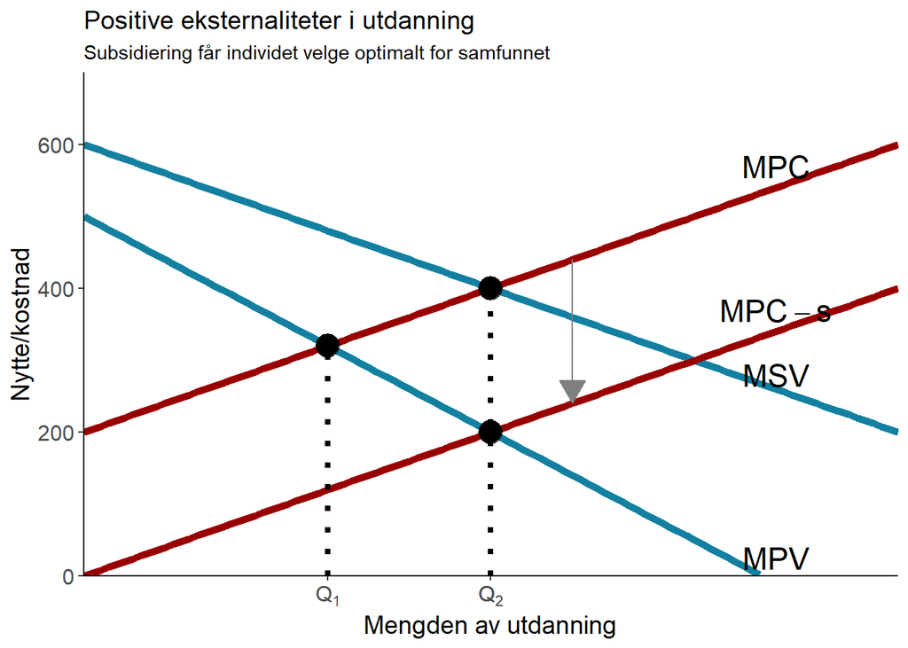

```r
library(ggplot2)
library(econocharts)
library(dplyr)
library(devtools)
install_github("andrewheiss/reconPlots")
library(reconPlots)

# Definer funksjonene
MPV <- function(x) 500 - 60*x
# Step 2: Create a sequence of y-values
y_values <- MPV(seq(0, 10, by = 0.1))
# Step 3: Create a data frame
df_MPV <- data.frame(x = seq(0, 10, by = 0.1), y = y_values)

MSV <- function(x) 600 - 40*x
y_values <- MSV(seq(0, 10, by = 0.1))
df_MSV <- data.frame(x = seq(0, 10, by = 0.1), y = y_values)

MPC <- function(x) 200 + 40*x
y_values <- MPC(seq(0, 10, by = 0.1))
df_MPC <- data.frame(x = seq(0, 10, by = 0.1), y = y_values)

MPC_s <- function(x) 200 + 40*x - 200  # Med subsidie
y_values <- MPC_s(seq(0, 10, by = 0.1))
df_MPC_s <- data.frame(x = seq(0, 10, by = 0.1), y = y_values)

# Calculate the intersections of the  curves
intersections <- bind_rows(curve_intersect(MPV, MPC, empirical = FALSE,domain = c(0, 8)),
                           curve_intersect(MSV, MPC, empirical = FALSE,domain = c(0, 8)),
                           curve_intersect(MPV, MPC_s, empirical = FALSE,domain = c(0, 8)))

plot_labels <- data_frame(label = c("MPV", "MSV", "MPC","MPC-s"),
                          x = c(8.5, 8.5, 8.5,8.5),
                          y = c(25, 280, 570,370))

ggplot(mapping = aes(x = x, y = y)) +
  geom_path(data = df_MPV, color = "#1380A1", size = 2) +
  geom_path(data = df_MSV, color = "#1380A1", size = 2) +
  geom_path(data = df_MPC, color = "#990000", size = 2) +
  geom_path(data = df_MPC_s, color = "#990000", size =2 ) +
  geom_segment(data = intersections,
               aes(x = x, y = 0, xend = x, yend = y), lty = "dotted",size=1.5) +
  #geom_segment(data = intersections,
  #             aes(x = 0, y = y, xend = x, yend = y), lty = "dotted") +
  geom_text(data = plot_labels,
            aes(x = x, y = y, label = label), parse = TRUE,size=6,
            family = "Source Sans Pro") +
  annotate("segment", x = 6, xend = 6, y = 440, yend = 240,
           arrow = arrow(length = unit(1, "lines"), type = "closed"), colour = "grey50") +
  geom_point(data = intersections, size = 6) +
  scale_x_continuous(limits = c(0, 10), expand = c(0, 0), breaks = intersections$x,
                 labels = expression(Q[1], Q[2],Q[2])) +
  scale_y_continuous(limits = c(0, 700),expand = c(0, 0))+
  labs(x = "Mengden av utdanning", y = "Nytte/kostnad",
       title = "Positive eksternaliteter i utdanning",
       subtitle = "Subsidiering får individet velge optimalt for samfunnet") +
  #coord_equal() +
  theme_classic(base_family = "Source Sans Pro") +
  theme(plot.title = element_text(family = "Source Sans Pro Semibold", size = rel(1.3)),
        axis.text.x = element_text(size = 12),      # Font size for x-axis text
        axis.text.y = element_text(size = 12),      # Font size for y-axis text
        axis.title.x = element_text(size = 14),     # Font size for x-axis title
        axis.title.y = element_text(size = 14))     # Font size for y-axis title
```

## Oppgave 3

- Anta en risikoavers person
- hvis hun er frisk, har hun inntekt, $W = 100000$
- hvis hun er syk, vil hun lide et økonomisk tap, $L = 50000$, som resulterer i inntekt $W - L = 50000$
- sannsynligheten for sykdom er $q = 0,2$, og sannsynligheten for å ikke være syk $1 - q = 0,8$
1. Aktuarielt rettferdig premie er $\pi = qL = 0,2*50000 = 10000$
2. Forventet nytte **uten forsikring** (punkt A) er $E(U) = (1 - q)U(W) + qU(W - L) = (1 - 0,2)*\sqrt{100000} + 0,2*\sqrt{500000} \approx 297,7$. Forventet nytte er et vektet gjennomsnitt av nytten av hvert mulig utfall, hvor vekten for hvert utfall er sannsynligheten for at det utfallet inntreffer. Nytten **med forsikring** (punkt B) er

$$U(W - qL) = \sqrt{100000 - 0,2*50000} = \sqrt{90000} = 300$$

Forventet nytte med forsikring er høyere enn uten forsikring for en risikoavers person. Det er med andre ord knyttet velferdsgevinster til det å ha helseforsikring. Selv om den forventede monetære kostnaden er den samme med og uten forsikring, vil mange mennesker kjøpe forsikring fordi den forventede nytten av å være forsikret er høyere enn den forventede nytten av ikke å være det. Dette skyldes at nyttekurven ofte er sterkt konkav.

## Oppgave 4

1. Uheldig utvalg, også kjent som “adverse selection”, oppstår når kjøpere og selgere har ulik informasjon om varen eller tjenesten som blir omsatt. I denne sammenhengen vet hver enkelt viking om han er en berserker eller en kontrollert viking, men forsikringsselskapet vet det ikke. Når forsikringsselskapet setter en enhetspris for alle, kan prisen bli for høy for de kontrollerte vikingene, men for lav for berserkerne. Dette kan føre til at førstnevnte gruppe velger bort forsikringen, mens sistnevnte gruppe melder seg på. Resultatet er at forsikringsselskapet ender opp med en overvekt av risikable kunder (berserkerne) sammenlignet med hva de hadde forventet basert på en blandet gruppe. Dette kan lede til høyere utbetalinger enn forventet og kan potensielt skade selskapets finansielle stabilitet.
2. Atferdsrisiko, også kjent som “moral hazard”, oppstår når folk endrer sin oppførsel som en respons på det faktum at de er forsikret, og dermed tar større risikoer enn de ville ha gjort ellers. Når Eysteinn , for eksempel, bestemmer seg for å ta risikoen med å hoppe mellom klippene, gjør han det fordi han vet at han har en forsikring som vil dekke ham hvis noe går galt.
3. Når vikinger som Eysteinn endrer oppførselen sin til å ta større risiko, øker sannsynligheten for ulykker og skader. Dette kan føre til høyere krav. Med en høyere frekvens av krav kan forsikringspremiene øke for å dekke de økte kostnadene. I tillegg kan man oppleve kapasitetsproblemer hvis for mange vikinger krever medisinsk behandling samtidig.
4. Den tvungne helseforsikringen kan potensielt minske problemet med uheldig utvalg ved at alle, både berserkere og kontrollerte vikinger, er inkludert i forsikringspoolen. Dette kan sikre en balansert risikosammensetning og kan også forhindre at bare høyrisikokunder kjøper forsikring. Imidlertid kan ikke den tvungne helseforsikringen i seg selv løse problemet med atferdsrisiko. Det faktum at folk tar større risiko fordi de er forsikret er et atferdsproblem, og løsningen ligger ofte i å innføre tiltak som motiverer folk til å oppføre seg ansvarlig, som for eksempel egenandeler ved skader som følge av unødvendig risikabel oppførsel.

## Oppgave 5

a. Likevekten finner vi der $P = 1000 - 250Q = 500 = MC$. Vi løser dette med hensyn på $Q$, og finner at likevekten er $Q = 2$ legebesøk per år. Total kostnad for individet blir da $kr\ 500 \times 2\ = \ kr\ 1000$.

b. Innføringen av helseforsikring i form av egenandel har ført til at det etterspurte antallet legebesøk økte fra 2 til 3. Dette skjedde fordi prisen som konsumenten måtte betale gikk ned fra 500 til 250 kroner. Prisen gikk altså ned, men marginalkostnaden forble den samme, 500 kroner, per legebesøk. Dette betyr at individet konsumerer legetjenester på et nivå der marginalnytten er lavere enn marginalkostnaden. Dette fører til ineffektivitet og skaper dødvektstap som her er likt

$$\frac{(3 - 2)*250}{2} = 125$$

> Størrelsen på dødvektstapet øker jo lavere egenandel er. Det er også meget avhengig av etterspørselskurvens elastisitet: jo mer elastisk etterspørselskurve, desto større dødvektstap.

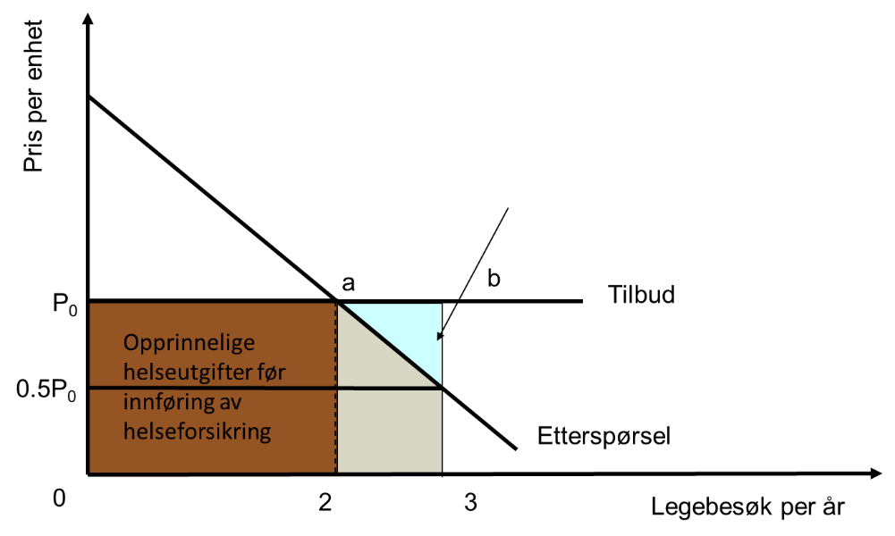

3. Individet konsumerer legetjenester på et nivå der marginalnytten er lavere enn marginalkostnaden
4. Mer nødvendige helsetjenester, for eksempel livsviktige operasjoner er prisufølsomme. Med andre ord er etterspørselen meget uelastisk. Vi har illustrert dette i diagrammet til høyre nedenfor. Etterspørselen av en del helsetjenester kan sies å være mer priselastiske, helsetjenesten kan for eksempel ha andre subsitutter slik som selvkonsultering pr. internett. Denne situasjonen er tegnet i diagrammet til venstre. Vi ser (vi antar den samme egenandelsbetalingen i begge tilfeller) at dødvektstapet og merforbruket ($M_{1} - M_{0})$, som følge av egenandelsbetaling, er mye større for helsetjenester der etterspørselen er priselastisk. Dette resultatet impliserer at det ville vært effektivt å operere med høyere egenandelsprosenter i helsetjenester som har elastisk etterspørsel.

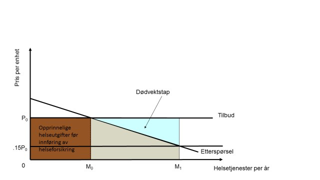

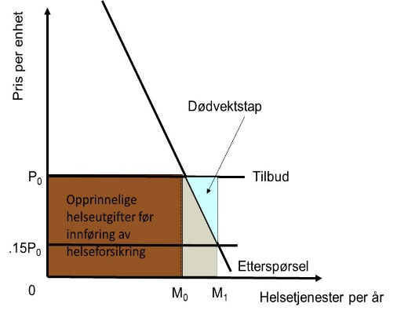